# homework10

Shangsi Lin

2023-05-03

#### Qusetion 1

```r
# load data
log_rank_data = tibble(time = c(c(4,12,15,21,23), c(2,6,8,10,19)),
              cens= c(c(1, 0, 1, 0, 1), c(1, 0, 0, 1, 1)),
              treat = c(rep(1, 5), rep(2, 5)))
# test if h1(t) = h2(t) for some t using the log-rank test
survdiff(Surv(time, cens) ~ treat, data = log_rank_data)
```

```
## Call:
## survdiff(formula = Surv(time, cens) ~ treat, data = log_rank_data)
##
##         N Observed Expected (O-E)^2/E (O-E)^2/V
## treat=1 5        3     4.14     0.313      1.15
## treat=2 5        3     1.86     0.697      1.15
##
##  Chisq= 1.1  on 1 degrees of freedom, p= 0.3
```

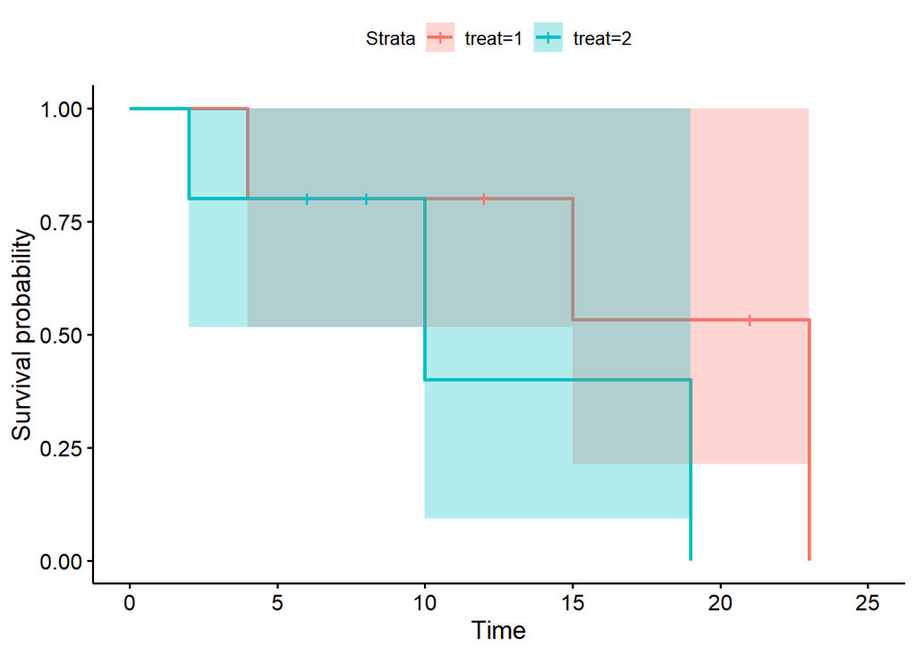

```r
ggsurvplot(survfit(Surv(time, cens) ~ treat, data = log_rank_data), conf.int = TRUE)
```

According to the result of the log rank test, the p-value is 0.3 which is larger than 0.05, hence we have failed to reject the null hypothesis. WE conclude that h1(t) = h2(t).

#### Question 2

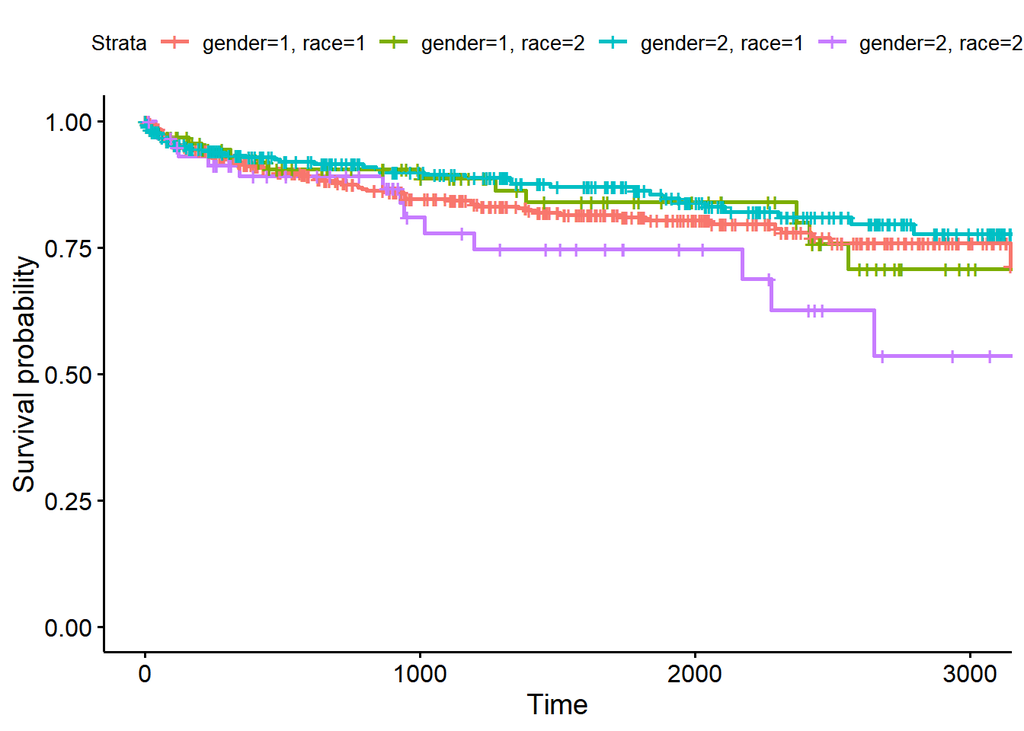

```r
# Compare the survival curves for different races in each sex group in the kidtran dataset.
data("kidtran")
ggsurvplot(survfit(Surv(time, delta) ~ gender + race, data = kidtran), conf.int = FALSE)
```

```r
# Male group
survdiff(Surv(time, delta) ~ race, data = kidtran, subset = (gender == 1))
```

```
## Call:
## survdiff(formula = Surv(time, delta) ~ race, data = kidtran,
##     subset = (gender == 1))
##
##          N Observed Expected (O-E)^2/E (O-E)^2/V
## race=1 432       73     71.9    0.0168     0.097
## race=2  92       14     15.1    0.0801     0.097
##
##  Chisq= 0.1  on 1 degrees of freedom, p= 0.8
```

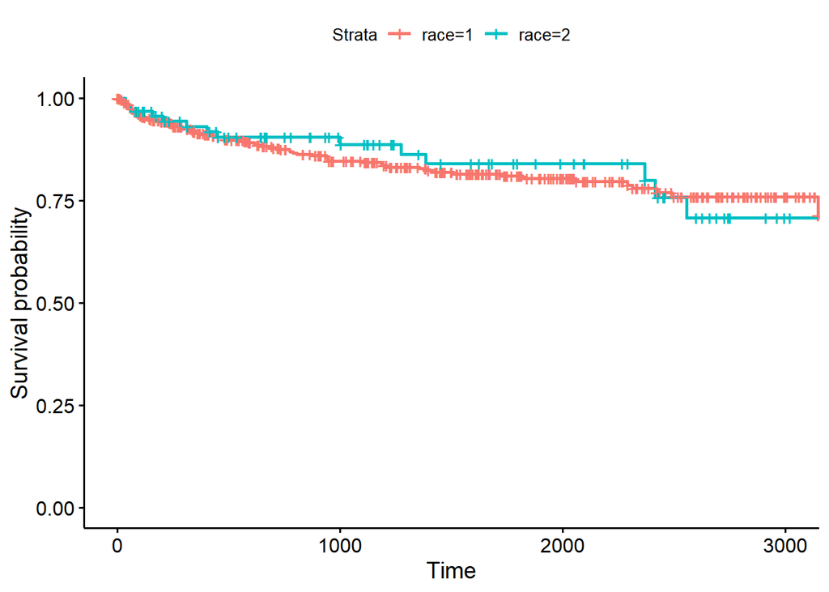

```r
ggsurvplot(survfit(Surv(time, delta) ~ race, data = subset(kidtran, gender == 1)), conf.int = FALSE)
```

```r
# Female group
survdiff(Surv(time, delta) ~ race, data = kidtran, subset = (gender == 2))
```

```
## Call:
## survdiff(formula = Surv(time, delta) ~ race, data = kidtran,
##     subset = (gender == 2))
##
##          N Observed Expected (O-E)^2/E (O-E)^2/V
## race=1 280       39    44.79     0.748      4.85
## race=2  59       14     8.21     4.076      4.85
##
##  Chisq= 4.8  on 1 degrees of freedom, p= 0.03
```

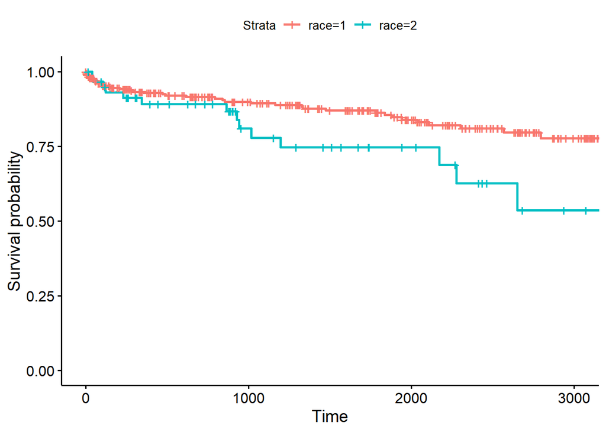

```r
ggsurvplot(survfit(Surv(time, delta) ~ race, data = subset(kidtran, gender == 2)), conf.int = FALSE)
```

Regarding the log-rank test for the male group, the p-value is 0.8 which is larger than 0.05 so we have failed to reject the null hypothesis. We conclude that there is no significant difference between the survival of the two race groups in the male group. From the curve we can see that the white race represented by race 1 had a lower survival probability in the beginning, but eventually higher than the black race after time unit passes around 2400. Regarding the log-rank test for the female group, the p-value is 0.03 which is smaller than 0.05 so we have rejected the null hypothesis. We conclude that there is significant difference between the survival of the two race groups in the female group. From the curve we can see that the white race represented by race 1 had a higher survival probability compared to the black race for the whole time period.

#### Question 3

```r
data("larynx")
# fir a proportional hazards model using the covariates Z1, Z2, Z3, Z4 and the interaction term Z1 * Z4
larynx_data = larynx %>%
  mutate(Z1 = ifelse(larynx$stage == 2, 1, 0),
         Z2 = ifelse(larynx$stage == 3, 1, 0),
         Z3 = ifelse(larynx$stage == 4, 1, 0),
         Z4 = larynx$age)

ph_model = coxph(Surv(time, delta) ~ Z1 + Z2 + Z3 + Z4 + Z1 * Z4, data = larynx_data, ties = 'breslow')
summary(ph_model)
```

```
## Call:
## coxph(formula = Surv(time, delta) ~ Z1 + Z2 + Z3 + Z4 + Z1 *
##     Z4, data = larynx_data, ties = "breslow")
##
##   n= 90, number of events= 50
##
##             coef  exp(coef)   se(coef)      z Pr(>|z|)
## Z1    -7.3820143  0.0006223  3.4027542 -2.169   0.0301 *
## Z2     0.6218044  1.8622853  0.3558078  1.748   0.0805 .
## Z3     1.7534270  5.7743576  0.4239595  4.136 3.54e-05 ***
## Z4     0.0059729  1.0059908  0.0148792  0.401   0.6881
## Z1:Z4  0.1116674  1.1181409  0.0476728  2.342   0.0192 *
## ---
## Signif. codes:  0 '***' 0.001 '**' 0.01 '*' 0.05 '.' 0.1 ' ' 1
##
##       exp(coef) exp(-coef) lower .95 upper .95
## Z1    0.0006223  1606.8231 7.900e-07    0.4903
## Z2    1.8622853     0.5370 9.272e-01    3.7403
## Z3    5.7743576     0.1732 2.516e+00   13.2550
## Z4    1.0059908     0.9940 9.771e-01    1.0358
## Z1:Z4 1.1181409     0.8943 1.018e+00    1.2277
##
## Concordance= 0.682  (se = 0.04 )
## Likelihood ratio test= 24.11  on 5 df,   p=2e-04
## Wald test            = 23.77  on 5 df,   p=2e-04
## Score (logrank) test = 27.98  on 5 df,   p=4e-05
```

From the summary table generated above, the results are interpreted as follows:

Keeping time and age constant, the hazard ratio for a stage II individual compared to a stage I individual is 0.000622.

Keeping time and age constant, the hazard ratio for a stage III individual compared to a stage I individual is 1.862.

Keeping time and age constant, the hazard ratio for a stage IV individual compared to a stage I individual is 5.774.

Keeping time and stage constant, the hazard ratio increases by 1.006 per a unit increase in age.

Keeping time constant, the hazard ratio for a stage II individual increases by 1.118 per a unit increase in age.